# Supplementary materials to the paper “Machine learning prediction models for donor Hb deferral: can we use the same models across countries?”

# Results

We repeated the simulation procedure 300 times for various deferral rates (1, 2, 4, 8, 16%) as shown in Figure 4. Deferral rates were set by adjusting the mean population Hb levels accordingly. Figure 5 and Figure 8 show the cAUPR and AUROC estimates for RF models trained and tested at various deferral rates. These figures clearly show that both the cAUPR and AUROC estimates increase with an increase in donor deferral rate. Also, these figures show that the cAUPR is more sensitive to changes between the models tested at various deferral rates. This is because the AUPR is sensitive changes in the positive predictive value (or precision) of the model whereas the AUROC is not. This is the main reason that AUPR performance measures are recommended for evaluating models with unbalanced binary class outcomes (Saito and Rehmsmeier (2015)). In Figure 6 the AUPR estimates for RF models for various deferral rates are shown again, but now the results for models trained at all deferral rate levels applied to all deferral rate test data are shown as well. These results are provided in numerical form in Table 1. Figure 9 and Table 2 provide the same information for AUROC estimates. From Figure 6 and Figure 9 it can be found that models trained on data sets with higher deferral rates generally have a (slightly) better performance than model trained on dataset with lower deferral rates. Figure 7 and Figure 10 show the result of applying these models to test datasets with a lower measurement error (0.25 instead of 0.50 mmol/L) but identical preset deferral rates. These figures clearly show the increase in performance of the prediction models when measurements are more accurate. The data presented in these figures is also provided in Table 1 and Table 2.

**Code simulation**

```r
if(F){ # redo the simulation
  # do the simulation for n samples
  set.seed(1)
  dosim(nrsimulations)

  # write results to file
saveRDS(list(n=n, props=props, trainprop=trainprop, testprop=testprop, MeasSds=MeasSds,
            PopSd=PopSd, threshold=threshold, nr_meas=nr_meas,
            tedao=tedao, trdao=trdao, dsc=dsc, dsc2=dsc2), file=paste0("SimresMatrix_",nrsimulations,"sim.rds"))
}

res<-readRDS(paste0("SimresMatrix_",nrsimulations,"sim.rds"))
str(res)
dsc<-res$dsc
dsc2<-res$dsc2
tedao<-res$tedao
trdao<-res$trdao
props<-res$props
trainprop<-res$trainprop
testprop<-res$trainprop
MeasSds<-res$MeasSds
PopSd<-res$PopSd
threshold<-res$threshold
nr_meas<-res$nr_meas
# Calculate mean, sd, UL and LL AUPR/ROC values per combination of proportion of deferrals and measurement uncertainty
lp<-length(props)
lm<-length(MeasSds)
```

**Code performance statistics (cAUPR)**

```r
auind<-1 # selection for AUPR (1) or ROC values (2)
aucor<-T # area under the curve is corrected (T) or not (F)
calcMedian<-F


for (l in 1:lm){
  eval(parse(text=paste0("auMean",l,"<-matrix(0, nrow=lp, ncol=lp)")))
  eval(parse(text=paste0("auSd"  ,l,"<-matrix(0, nrow=lp, ncol=lp)")))
  eval(parse(text=paste0("auUL"  ,l,"<-matrix(0, nrow=lp, ncol=lp)")))
  eval(parse(text=paste0("auLL"  ,l,"<-matrix(0, nrow=lp, ncol=lp)")))

  eval(parse(text=paste0("dscMean",l,"<-matrix(0, nrow=lp, ncol=lp)")))
  eval(parse(text=paste0("dscSd"  ,l,"<-matrix(0, nrow=lp, ncol=lp)")))
  eval(parse(text=paste0("dscUL"  ,l,"<-matrix(0, nrow=lp, ncol=lp)")))
  eval(parse(text=paste0("dscLL"  ,l,"<-matrix(0, nrow=lp, ncol=lp)")))
  for (i in 1:lp){
    for (j in 1:lp){
      eval(parse(text=paste0("auMean",l,"[i,j]<-mean(tedao    [,i,j,",l,",auind])")))
      if(calcMedian) eval(parse(text=paste0("auMean",l,"[i,j]<-median(tedao    [,i,j,",l,",auind])")))
      eval(parse(text=paste0("auSd"  ,l,"[i,j]<-sd(tedao      [,i,j,",l,",auind])")))
      eval(parse(text=paste0("auUL"  ,l,"[i,j]<-quantile(tedao[,i,j,",l,",auind],.975)")))
      eval(parse(text=paste0("auLL"  ,l,"[i,j]<-max(0,quantile(tedao[,i,j,",l,",auind],.025))")))
      if (auind==1 & aucor==T){ # calculated corrected AUPR values
        eval(parse(text=paste0("auMean",l,"[i,j]<-mean(tedao    [,i,j,",l,",auind]-dsc2[,i,j,",l,"])")))
        if(calcMedian) eval(parse(text=paste0("auMean",l,"[i,j]<-median(tedao    [,i,j,",l,",auind]-dsc2[,i,j,",l,"])")))
        eval(parse(text=paste0("auSd"  ,l,"[i,j]<-sd(tedao      [,i,j,",l,",auind]-dsc2[,i,j,",l,"])")))
        eval(parse(text=paste0("auUL"  ,l,"[i,j]<-quantile(tedao[,i,j,",l,",auind]-dsc2[,i,j,",l,"],.975)")))
        eval(parse(text=paste0("auLL"  ,l,"[i,j]<-max(0,quantile(tedao[,i,j,",l,",auind]-dsc2[,i,j,",l,"],.025))")))
      }

      eval(parse(text=paste0("dscMean",l,"[i,j]<-mean(dsc2    [,i,j,",l,"])")))
      if(calcMedian) eval(parse(text=paste0("dscMean",l,"[i,j]<-median(dsc2    [,i,j,",l,"])")))
      eval(parse(text=paste0("dscSd"  ,l,"[i,j]<-sd(dsc2      [,i,j,",l,"])")))
      eval(parse(text=paste0("dscUL"  ,l,"[i,j]<-quantile(dsc2[,i,j,",l,"],.975)")))
      eval(parse(text=paste0("dscLL"  ,l,"[i,j]<-quantile(dsc2[,i,j,",l,"],.025)")))
    }
  }
}
auMean1
auMean2
auUL1
auLL1

auMean<-apply(trdao[,,auind],2,mean)
if(calcMedian) auMean<-apply(trdao[,,auind],2,median)
auSd  <-apply(trdao[,,auind],2,sd)
auUL  <-apply(trdao[,,auind],2,function (x) quantile(x,0.975))
auLL  <-apply(trdao[,,auind],2,function (x) quantile(x,0.025))
if (auind==1 & aucor==T){ # calculated corrected AUPR values
  auMean<-apply(trdao[,,auind]-dsc,2,mean)
  if(calcMedian) auMean<-apply(trdao[,,auind]-dsc,2,median)
  auSd  <-apply(trdao[,,auind]-dsc,2,sd)
  auUL  <-apply(trdao[,,auind]-dsc,2,function (x) quantile(x,0.975))
  auLL  <-apply(trdao[,,auind]-dsc,2,function (x) quantile(x,0.025))
}
(dscMean<-apply(dsc,2,mean))
if(calcMedian) (dscMean<-apply(dsc,2,median))
dscUL   <-apply(dsc,2,function (x) quantile(x,0.975))
dscLL   <-apply(dsc,2,function (x) quantile(x,0.025))
auMean
auUL
auLL
```

**Code plot**

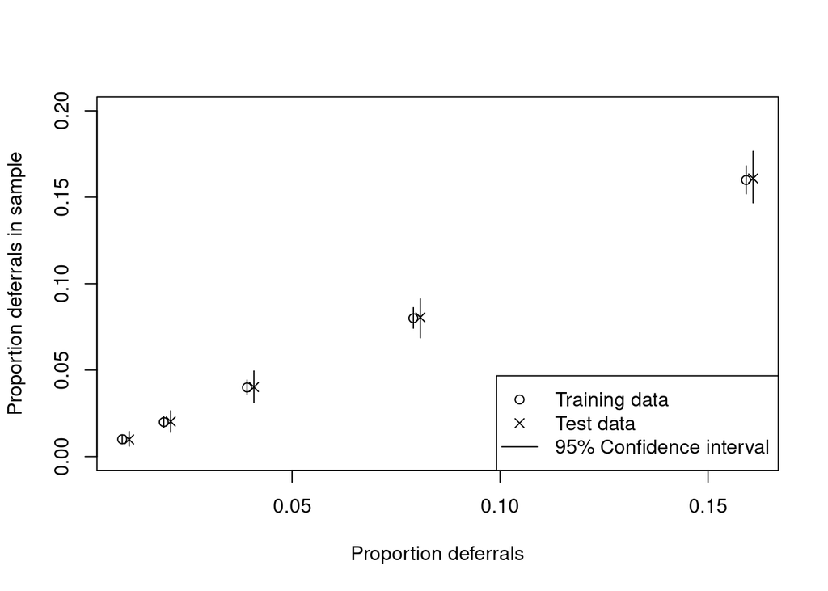

Figure 4: The proportion of donors below the deferral threshold for the training and test data sets in the simulation as function of the preset proportion of deferral (1%, 2%, 4%, 8% and 16%).

```r
d<-min(props)/12
plot(c(props-d,props+d),c(dscMean,diag(dscMean1)), pch=rep(c(1,4),each=lp), ylim=c(0,.2),
     ylab="Proportion deferrals in sample", xlab="Proportion deferrals")
for (i in 1:lp) {
  lines(rep(props[i]-d,2),c(dscLL [i],   dscUL [i]))
  lines(rep(props[i]+d,2),c(dscLL1[i,i], dscUL1[i,i]))
}
legend("bottomright", c("Training data", "Test data", "95% Confidence interval"), lty=c(NA,NA,1), pch=c(1,4,NA))
```

## cAUPR

**Code plot**

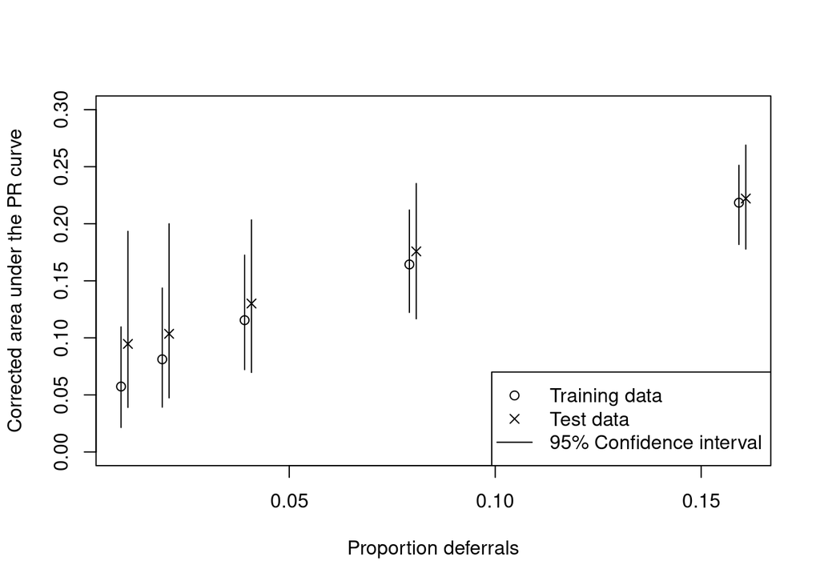

Figure 5: Mean area under the corrected precision-recall curve (cAUPR) over all simulations and the spread in the estimates for the individual training and test data sets as a function of the proportion of deferrals.

```r
# plot AUPR/ROC results
if(auind==1){
  if (aucor==T){ # corrected AUPR values
    plot(c(props-d,props+d),c(auMean,diag(auMean1)), pch=rep(c(1,4),each=lp), ylim=c(0,.3),
         ylab="Corrected area under the PR curve", xlab="Proportion deferrals")
  } else { # corrected AUPR values
    plot(c(props-d,props+d),c(auMean,diag(auMean1)), pch=rep(c(1,4),each=lp), ylim=c(0,.5),
       ylab="Area under the PR curve", xlab="Proportion deferrals")
  }
} else {
    plot(c(props-d,props+d),c(auMean,diag(auMean1)), pch=rep(c(1,4),each=lp), ylim=c(0,1),
         ylab="Area under the ROC curve", xlab="Proportion deferrals")
}
for (i in 1:lp) {
  lines(rep(props[i]-d,2),c(auLL[i], auUL[i]))
  lines(rep(props[i]+d,2),c(auLL1[i,i], auUL1[i,i]))
}
legend("bottomright", c("Training data", "Test data", "95% Confidence interval"), lty=c(NA,NA,1), pch=c(1,4,NA))
if(auind==2) abline(h=max(auMean), col=8, lty=2)
```

**Code plot**

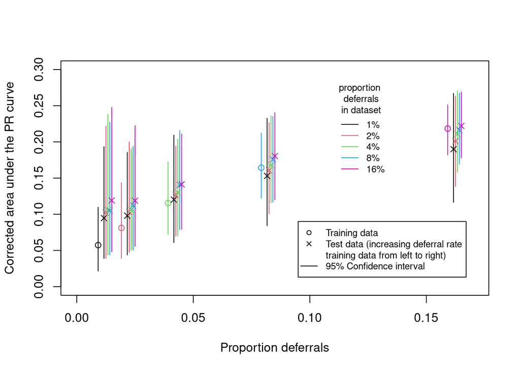

Figure 6: Mean area under the corrected precision-recall curve (cAUPR) and the spread in the estimates for the individual training and test data sets as a function of the proportion of deferrals. Models developed on training data at each of the deferral proportion levels are applied on all test datasets.

```r
# create plots
# plot main training results
cols<-c(1,2,3,4,6)
plotboth <- F
if(auind==1) { # AUPR plots
  if (aucor==T){ # corrected AUPR values
    ylab="Corrected area under the PR curve"
    if(plotboth){
      ylim<-c(0,0.45)
    } else { # if plotted with alternative deferral probability dataset
      ylim<-c(0,0.3)
    }
  } else {
    ylab="Area under the PR curve"
    if(plotboth){
      ylim<-c(0,0.65)
    } else { # if plotted with alternative deferral probability dataset
      ylim<-c(0,0.5)
    }
  }
} else { # AUROC plots
  ylab="Area under the AUROC curve"
  if(plotboth){
    ylim<-c(.5,1)
  } else { # if plotted with alternative deferral probability dataset
    ylim<-c(.5,.9)
  }
}
plot(props-d,auMean, pch=rep(1,lp), ylim=ylim, xlim=c(0,0.17), col=cols,
     ylab=ylab, xlab="Proportion deferrals")
# add training uncertainty
for (i in 1:lp) lines(rep(props[i]-d,2),c(auLL[i], auUL[i]), col=cols[i])
# add validation results and uncertainty estimates
for (i in 1:lp) {
  lines(rep(props[i]+2*d,2), c(auLL1[1,i], auUL1[1,i]), col=cols[1])
  lines(rep(props[i]+3*d,2), c(auLL1[2,i], auUL1[2,i]), col=cols[2])
  lines(rep(props[i]+4*d,2), c(auLL1[3,i], auUL1[3,i]), col=cols[3])
  lines(rep(props[i]+5*d,2), c(auLL1[4,i], auUL1[4,i]), col=cols[4])
  lines(rep(props[i]+6*d,2), c(auLL1[5,i], auUL1[5,i]), col=cols[5])

  points(props[i]+2*d, auMean1[1,i], pch=4, col=cols[1])
  points(props[i]+3*d, auMean1[2,i], pch=4, col=cols[2])
  points(props[i]+4*d, auMean1[3,i], pch=4, col=cols[3])
  points(props[i]+5*d, auMean1[4,i], pch=4, col=cols[4])
  points(props[i]+6*d, auMean1[5,i], pch=4, col=cols[5])

  if (F) {
    points(props[i]+2*d, auUL1[1,i], pch=1)
    points(props[i]+3*d, auUL1[2,i], pch=1)
    points(props[i]+4*d, auUL1[3,i], pch=1)
    points(props[i]+5*d, auUL1[4,i], pch=1)
    points(props[i]+6*d, auUL1[5,i], pch=1)

    points(props[i]+2*d, auLL1[1,i], pch=1)
    points(props[i]+3*d, auLL1[2,i], pch=1)
    points(props[i]+4*d, auLL1[3,i], pch=1)
    points(props[i]+5*d, auLL1[4,i], pch=1)
    points(props[i]+6*d, auLL1[5,i], pch=1)
  }
}

# add legends
legend(0.11,ylim[1]+.85*(ylim[2]-ylim[1]), paste0(props*100,"%"), title="proportion \ndeferrals\nin dataset",
       col=cols, lty=rep(1,lp), box.col=0, cex=0.75)
if(!plotboth){
  legend(0.095, ylim[1]+.3*(ylim[2]-ylim[1]), c("Training data", "Test data (increasing deferral rate",
          "training data from left to right)", "95% Confidence interval"),
           lty=c(NA,NA,NA,1), pch=c(1,4,NA,NA), cex=0.75)
}
```

**Code table**

```r
aupr05 <- matrix(nrow=nrow(auMean1), ncol = ncol(auMean1)+ncol(auSd1))
for(i in 1:5){
  aupr05[1:5,(2*i)-1] <- auMean1[1:5,i]
  aupr05[1:5,(2*i)] <- auSd1[1:5,i]
}

aupr025 <- matrix(nrow=nrow(auMean2), ncol = ncol(auMean2)+ncol(auSd2))
for(i in 1:5){
  aupr025[,(2*i)-1] <- auMean2[,i]
  aupr025[,(2*i)] <- auSd2[,i]
}

rownames<- c("Training 1%", "Training 2%", "Training 4%", "Training 8%", "Training 16%")
colnames<- c("cAUPR", "Sd", "cAUPR", "Sd","cAUPR", "Sd","cAUPR", "Sd","cAUPR", "Sd")

auprtable <- rbind(aupr05, aupr025)
rownames(auprtable)<-c(rownames, rownames)
colnames(auprtable)<-colnames
kable(auprtable,
      digits=3,
      row.names=T
      )%>% add_header_above(c(" " = 1,"Test 1%"=2, "Test 2%"=2, "Test 4%"=2, "Test 8%"=2, "Test 16%"=2)) %>% pack_rows(index = c("Measurement error 0.5 mmol/L" = 5, "Measurement error 0.25 mmol/L" = 5))
```

|  | Test 1% cAUPR | Test 1% Sd | Test 2% cAUPR | Test 2% Sd | Test 4% cAUPR | Test 4% Sd | Test 8% cAUPR | Test 8% Sd | Test 16% cAUPR | Test 16% Sd |
| --- | --- | --- | --- | --- | --- | --- | --- | --- | --- | --- |
| **Measurement error 0.5 mmol/L** |  |  |  |  |  |  |  |  |  |  |
| Training 1% | 0.095 | 0.043 | 0.098 | 0.038 | 0.120 | 0.038 | 0.153 | 0.037 | 0.190 | 0.041 |
| Training 2% | 0.102 | 0.048 | 0.104 | 0.039 | 0.127 | 0.035 | 0.160 | 0.033 | 0.201 | 0.032 |
| Training 4% | 0.106 | 0.051 | 0.106 | 0.040 | 0.130 | 0.035 | 0.168 | 0.029 | 0.211 | 0.028 |
| Training 8% | 0.105 | 0.049 | 0.112 | 0.041 | 0.141 | 0.037 | 0.176 | 0.032 | 0.216 | 0.026 |
| Training 16% | 0.119 | 0.055 | 0.119 | 0.043 | 0.141 | 0.035 | 0.180 | 0.032 | 0.222 | 0.025 |
| **Measurement error 0.25 mmol/L** |  |  |  |  |  |  |  |  |  |  |
| Training 1% | 0.166 | 0.077 | 0.180 | 0.070 | 0.216 | 0.062 | 0.257 | 0.059 | 0.301 | 0.065 |
| Training 2% | 0.172 | 0.068 | 0.194 | 0.064 | 0.222 | 0.054 | 0.269 | 0.052 | 0.309 | 0.048 |
| Training 4% | 0.183 | 0.076 | 0.190 | 0.061 | 0.234 | 0.050 | 0.274 | 0.041 | 0.319 | 0.037 |
| Training 8% | 0.178 | 0.068 | 0.202 | 0.055 | 0.237 | 0.050 | 0.287 | 0.043 | 0.323 | 0.029 |
| Training 16% | 0.189 | 0.078 | 0.206 | 0.059 | 0.244 | 0.049 | 0.290 | 0.039 | 0.331 | 0.027 |

Table 1: AUPR estimates and SD of Hb deferral prediction models developed on and applied to datasets with varying deferral rates and measurement errors.

**Code plot**

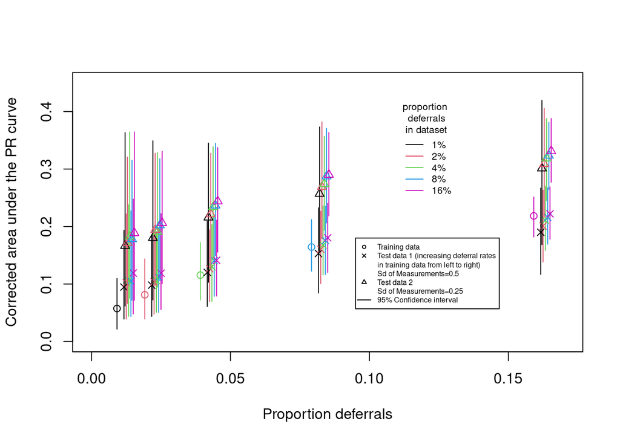

Figure 7: Mean area under the corrected precision-recall curve (cAUPR) and the spread in the estimates for the individual training and test data sets as a function of the proportion of deferrals. Models developed on training data at each of the deferral proportion levels are applied on all test datasets. In addition, cAUPR estimates for the prediction models are shown when applied to test datasets with lower measurement error (0.25 mmol/L).

```r
plotboth <- T
auind <- 1
if(auind==1) { # AUPR plots
  if (aucor==T){ # corrected AUPR values
    ylab="Corrected area under the PR curve"
    if(plotboth){
      ylim<-c(0,0.45)
    } else { # if plotted with alternative deferral probability dataset
      ylim<-c(0,0.3)
    }
  } else {
    ylab="Area under the PR curve"
    if(plotboth){
      ylim<-c(0,0.65)
    } else { # if plotted with alternative deferral probability dataset
      ylim<-c(0,0.5)
    }
  }
} else { # AUROC plots
  ylab="Area under the AUROC curve"
  if(plotboth){
    ylim<-c(.5,1)
  } else { # if plotted with alternative deferral probability dataset
    ylim<-c(.5,.9)
  }
}
plot(props-d,auMean, pch=rep(1,lp), ylim=ylim, xlim=c(0,0.17), col=cols,
     ylab=ylab, xlab="Proportion deferrals")
# add training uncertainty
for (i in 1:lp) lines(rep(props[i]-d,2),c(auLL[i], auUL[i]), col=cols[i])
# add validation results and uncertainty estimates
for (i in 1:lp) {
  lines(rep(props[i]+2*d,2), c(auLL1[1,i], auUL1[1,i]), col=cols[1])
  lines(rep(props[i]+3*d,2), c(auLL1[2,i], auUL1[2,i]), col=cols[2])
  lines(rep(props[i]+4*d,2), c(auLL1[3,i], auUL1[3,i]), col=cols[3])
  lines(rep(props[i]+5*d,2), c(auLL1[4,i], auUL1[4,i]), col=cols[4])
  lines(rep(props[i]+6*d,2), c(auLL1[5,i], auUL1[5,i]), col=cols[5])

  points(props[i]+2*d, auMean1[1,i], pch=4, col=cols[1])
  points(props[i]+3*d, auMean1[2,i], pch=4, col=cols[2])
  points(props[i]+4*d, auMean1[3,i], pch=4, col=cols[3])
  points(props[i]+5*d, auMean1[4,i], pch=4, col=cols[4])
  points(props[i]+6*d, auMean1[5,i], pch=4, col=cols[5])

  if (F) {
    points(props[i]+2*d, auUL1[1,i], pch=1)
    points(props[i]+3*d, auUL1[2,i], pch=1)
    points(props[i]+4*d, auUL1[3,i], pch=1)
    points(props[i]+5*d, auUL1[4,i], pch=1)
    points(props[i]+6*d, auUL1[5,i], pch=1)

    points(props[i]+2*d, auLL1[1,i], pch=1)
    points(props[i]+3*d, auLL1[2,i], pch=1)
    points(props[i]+4*d, auLL1[3,i], pch=1)
    points(props[i]+5*d, auLL1[4,i], pch=1)
    points(props[i]+6*d, auLL1[5,i], pch=1)
  }
}

# add legends
legend(0.11,ylim[1]+.85*(ylim[2]-ylim[1]), paste0(props*100,"%"), title="proportion \ndeferrals\nin dataset",
       col=cols, lty=rep(1,lp), box.col=0, cex=0.65)
if(!plotboth){
  legend(0.095, ylim[1]+.3*(ylim[2]-ylim[1]), c("Training data", "Test data (increasing deferral rate",
          "training data from left to right)", "95% Confidence interval"),
           lty=c(NA,NA,NA,1), pch=c(1,4,NA,NA),cex=0.5)
}

# plot validation plots for dataset with another measurement variability if required
if (plotboth) {
  d2=d/2
  auMean<-apply(trdao[,,2],2,mean)
  if(calcMedian) auMean<-apply(trdao[,,2],2,median)
  auSd  <-apply(trdao[,,2],2,sd)
  auLL  <-apply(trdao[,,2],2,function (x) quantile(x,0.975))
  auUL  <-apply(trdao[,,2],2,function (x) quantile(x,0.025))
  for (i in 1:lp) {
    lines(rep(props[i]+2*d+d2,2), c(auLL2[1,i], auUL2[1,i]), col=cols[1])
    lines(rep(props[i]+3*d+d2,2), c(auLL2[2,i], auUL2[2,i]), col=cols[2])
    lines(rep(props[i]+4*d+d2,2), c(auLL2[3,i], auUL2[3,i]), col=cols[3])
    lines(rep(props[i]+5*d+d2,2), c(auLL2[4,i], auUL2[4,i]), col=cols[4])
    lines(rep(props[i]+6*d+d2,2), c(auLL2[5,i], auUL2[5,i]), col=cols[5])

    points(props[i]+2*d+d2, auMean2[1,i], pch=2, col=cols[1])
    points(props[i]+3*d+d2, auMean2[2,i], pch=2, col=cols[2])
    points(props[i]+4*d+d2, auMean2[3,i], pch=2, col=cols[3])
    points(props[i]+5*d+d2, auMean2[4,i], pch=2, col=cols[4])
    points(props[i]+6*d+d2, auMean2[5,i], pch=2, col=cols[5])
  }
  legend(0.095, ylim[1]+.4*(ylim[2]-ylim[1]), c("Training data", "Test data 1 (increasing deferral rates",
          "in training data from left to right)", paste0("Sd of Measurements=",
          round(MeasSds[1],2)),  "Test data 2 ", paste0("Sd of Measurements=",
          round(MeasSds[2],2)),"95% Confidence interval"), cex=0.5,
          lty=c(NA,NA,NA,NA,NA,NA,1), pch=c(1,4,NA,NA,2,NA,NA))
}
if(auind==2) {
  abline(h=max(auMean), col=8, lty=2)
  legend(0.11,ylim[1]+.85*(ylim[2]-ylim[1]), paste0(props*100,"%"), title="proportion \ndeferrals\nin dataset",
       col=cols, lty=rep(1,lp), box.col=0, cex=0.75)
}
```